# Final Project

Yining Fan

12/13/2020

```r
# clean up workspace environment
rm(list = ls())
# packages
library(mosaic)
library(tidyverse)
library(DataComputing)
library(tidyr)
library(lubridate)
library(ggplot2)
```

```r
#Data
mydata = read.csv("daily_KP_UV_ALL.csv", header = T) #Primary data
mydata2=read.csv("daily_KP_MAXUV_ALL.csv", header = T)   #Other data source
```

## Data Analysis

### Guiding Question

How did the UV level changes through these years in Hong Kong?

### Details about data sources

1. Where did you find them?

Data founded in DATA.GOV.HK. (URL:https://data.gov.hk/en-data/dataset/hk-hko-rss-daily-maximum-mean-uv-index)

2. Who collected/maintains them?

HONG KONG OBSERVATORY. (No specific author specified)

3. When & Why were they originally collected?

Collected since 1999, update once a mouth. Intend to record the official UV levels for people in Hong Kong to check.

4. What does a case represent in each data source, and how many total cases are available?

```r
mydata %>%
  summarise(count = n())
```

| count |
| --- |
| 7730 |

```r
mydata2 %>%
  summarise(count = n())
```

| count |
| --- |
| 7730 |

Primary data: The mean UV value in a day with complete/uncomplete data.

Other data: The max UV value in a day with complete/uncomplete data.

There are 7730 cases in both data sets.

5. What are some of the variables that you plan to use

```r
names(mydata)
```

```
[1] "Year"         "Month"        "Day"          "Value"
[5] "Completeness"
```

```r
names(mydata2)
```

```
[1] "Year"         "Month"        "Day"          "Value"
[5] "Completeness"
```

I plan to use these 5 variables: year, mouth, day, value(quantitative) and data completeness(Catergorical).

```r
summary(mydata)
```

```
      Year          Month             Day            Value
 Min.   :1999   Min.   : 1.000   Min.   : 1.00   2      :2025
 1st Qu.:2004   1st Qu.: 4.000   1st Qu.: 8.00   3      :1826
 Median :2010   Median : 7.000   Median :16.00   4      :1147
 Mean   :2010   Mean   : 6.538   Mean   :15.73   1      : 761
 3rd Qu.:2015   3rd Qu.: 9.000   3rd Qu.:23.00   5      : 713
 Max.   :2020   Max.   :12.000   Max.   :31.00   6      : 462
                                                 (Other): 796
 Completeness
  :  11
 C:7719
```

```r
summary(mydata2)
```

```
      Year          Month             Day            Value
 Min.   :1999   Min.   : 1.000   Min.   : 1.00   5      :1055
 1st Qu.:2004   1st Qu.: 4.000   1st Qu.: 8.00   6      :1021
 Median :2010   Median : 7.000   Median :16.00   7      : 850
 Mean   :2010   Mean   : 6.538   Mean   :15.73   8      : 705
 3rd Qu.:2015   3rd Qu.: 9.000   3rd Qu.:23.00   9      : 631
 Max.   :2020   Max.   :12.000   Max.   :31.00   4      : 626
                                                 (Other):2842
 Completeness
  :   9
 C:7721
```

```r
str(mydata)
```

```
'data.frame':   7730 obs. of  5 variables:
 $ Year        : int  1999 1999 1999 1999 1999 1999 1999 1999 1999 1999 ...
 $ Month       : int  8 8 8 8 8 8 8 8 8 8 ...
 $ Day         : int  1 2 3 4 5 6 7 8 9 10 ...
 $ Value       : Factor w/ 17 levels "***","0.1","0.2",..: 17 13 13 13 14 13 13 15 12 14 ...
 $ Completeness: Factor w/ 2 levels "","C": 2 2 2 2 2 2 2 2 2 2 ...
```

```r
str(mydata2)
```

```
'data.frame':   7730 obs. of  5 variables:
 $ Year        : int  1999 1999 1999 1999 1999 1999 1999 1999 1999 1999 ...
 $ Month       : int  8 8 8 8 8 8 8 8 8 8 ...
 $ Day         : int  1 2 3 4 5 6 7 8 9 10 ...
 $ Value       : Factor w/ 22 levels "***","0.3","0.4",..: 12 21 21 22 11 21 20 11 19 10 ...
 $ Completeness: Factor w/ 2 levels "","C": 2 2 2 2 2 2 2 2 2 2 ...
```

```r
head(mydata)
```

|  | Year | Month | Day | Value | Completeness |
| --- | --- | --- | --- | --- | --- |
| 1 | 1999 | 8 | 1 | 7 | C |
| 2 | 1999 | 8 | 2 | 3 | C |
| 3 | 1999 | 8 | 3 | 3 | C |
| 4 | 1999 | 8 | 4 | 3 | C |
| 5 | 1999 | 8 | 5 | 4 | C |
| 6 | 1999 | 8 | 6 | 3 | C |

```r
head(mydata2)
```

|  | Year | Month | Day | Value | Completeness |
| --- | --- | --- | --- | --- | --- |
| 1 | 1999 | 8 | 1 | 13 | C |
| 2 | 1999 | 8 | 2 | 8 | C |
| 3 | 1999 | 8 | 3 | 8 | C |
| 4 | 1999 | 8 | 4 | 9 | C |
| 5 | 1999 | 8 | 5 | 12 | C |
| 6 | 1999 | 8 | 6 | 8 | C |

## Data Wrangling

```r
# filter out the uncomplete data.
thedata <-
mydata %>%
  filter(Completeness == "C") %>%
  select(Year,Month,Value,Completeness)
thedata
```

| Year | Month | Value | Completeness |
| --- | --- | --- | --- |
| 1999 | 8 | 7 | C |
| 1999 | 8 | 3 | C |
| 1999 | 8 | 3 | C |
| 1999 | 8 | 3 | C |
| 1999 | 8 | 4 | C |
| 1999 | 8 | 3 | C |
| 1999 | 8 | 3 | C |
| 1999 | 8 | 5 | C |
| 1999 | 8 | 2 | C |
| 1999 | 8 | 4 | C |

[output cut: 990 more lines]

```r
thedata2 <-
mydata2 %>%
  filter(Completeness == "C") %>%
  select(Year,Month,Value,Completeness)
thedata2
```

| Year | Month | Value | Completeness |
| --- | --- | --- | --- |
| 1999 | 8 | 13 | C |
| 1999 | 8 | 8 | C |
| 1999 | 8 | 8 | C |
| 1999 | 8 | 9 | C |
| 1999 | 8 | 12 | C |
| 1999 | 8 | 8 | C |
| 1999 | 8 | 7 | C |
| 1999 | 8 | 12 | C |
| 1999 | 8 | 6 | C |
| 1999 | 8 | 11 | C |

[output cut: 990 more lines]

```r
# How many datas in each year
thedata %>%
  group_by(Year) %>%
  summarise(count=n())
```

| Year | count |
| --- | --- |
| 1999 | 146 |
| 2000 | 364 |
| 2001 | 364 |
| 2002 | 364 |
| 2003 | 365 |
| 2004 | 366 |
| 2005 | 365 |
| 2006 | 365 |
| 2007 | 365 |
| 2008 | 366 |

[output cut: 12 more lines]

```r
thedata2 %>%
  group_by(Year) %>%
  summarise(count = n())
```

| Year | count |
| --- | --- |
| 1999 | 146 |
| 2000 | 364 |
| 2001 | 364 |
| 2002 | 364 |
| 2003 | 365 |
| 2004 | 366 |
| 2005 | 365 |
| 2006 | 365 |
| 2007 | 365 |
| 2008 | 366 |

[output cut: 12 more lines]

```r
Join <-
  thedata %>%
  inner_join(thedata2)
```

```
Column `Value` joining factors with different levels, coercing to character vector
```

```r
Join
```

| Year | Month | Value | Completeness |
| --- | --- | --- | --- |
| 1999 | 8 | 7 | C |
| 1999 | 8 | 7 | C |
| 1999 | 8 | 3 | C |
| 1999 | 8 | 3 | C |
| 1999 | 8 | 3 | C |
| 1999 | 8 | 4 | C |
| 1999 | 8 | 3 | C |
| 1999 | 8 | 3 | C |
| 1999 | 8 | 2 | C |
| 1999 | 8 | 2 | C |

[output cut: 990 more lines]

```r
#Using regular expression to compare the two data tables (difference between MAX and mean of UV value) in 1999
thedata %>%
  filter(grepl("1999", Year, ignore.case = TRUE))
```

| Year | Month | Value | Completeness |
| --- | --- | --- | --- |
| 1999 | 8 | 7 | C |
| 1999 | 8 | 3 | C |
| 1999 | 8 | 3 | C |
| 1999 | 8 | 3 | C |
| 1999 | 8 | 4 | C |
| 1999 | 8 | 3 | C |
| 1999 | 8 | 3 | C |
| 1999 | 8 | 5 | C |
| 1999 | 8 | 2 | C |
| 1999 | 8 | 4 | C |

[output cut: 136 more lines]

```r
thedata2 %>%
  filter(grepl("1999", Year, ignore.case = TRUE))
```

| Year | Month | Value | Completeness |
| --- | --- | --- | --- |
| 1999 | 8 | 13 | C |
| 1999 | 8 | 8 | C |
| 1999 | 8 | 8 | C |
| 1999 | 8 | 9 | C |
| 1999 | 8 | 12 | C |
| 1999 | 8 | 8 | C |
| 1999 | 8 | 7 | C |
| 1999 | 8 | 12 | C |
| 1999 | 8 | 6 | C |
| 1999 | 8 | 11 | C |

[output cut: 136 more lines]

```r
library(party)
CompleteData <-
  mydata %>%
  ctree(Completeness == "C" ~ Month + Year, data = .)
  CompleteData
```

```
     Conditional inference tree with 3 terminal nodes

Response:  Completeness == "C"
Inputs:  Month, Year
Number of observations:  7730

1) Year <= 1999; criterion = 1, statistic = 19.382
  2) Month <= 9; criterion = 0.987, statistic = 7.388
    3)*  weights = 61
  2) Month > 9
    4)*  weights = 92
1) Year > 1999
  5)*  weights = 7577
```

## Data Visualization

```r
June <-
  thedata %>%
  filter(Month == "6", Year == c(2010,2011,2012,2013,2014,2015))
```

```
longer object length is not a multiple of shorter object length
```

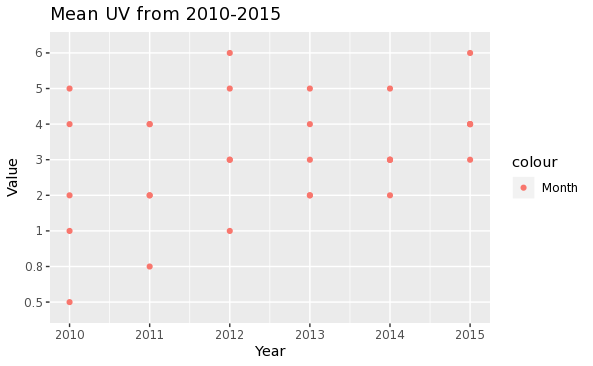

```r
ggplot(data=June,aes(x=Year,y=Value))+geom_point()+ggtitle("Mean UV from 2010-2015")+aes(colour="Month")
```

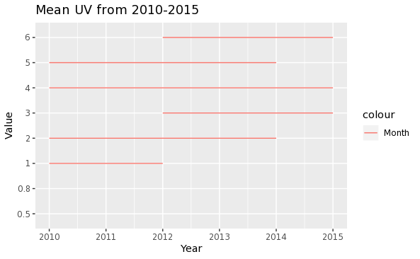

```r
ggplot(data=June,aes(x=Year,y=Value))+geom_line()+ggtitle("Mean UV from 2010-2015")+aes(colour="Month")
```

## About the project

### Guiding Question

How did the UV level changes through these years in Hong Kong?

### Why this topic is important?

Due to global warming, the temperature continues to rise every year. Like every summer we can see that this year is the hottest summer ever. For example, the highest temperature in 2000 was like 95 farenheight,but in this year the higest is like 106 farenheight. It’s not just temperature, the UV level also increases, which is the ultra violet.It could become to a problem in the near future.

### Challenge Encountered

1. Data wrangling: There are several uncomplete datas with no value. With this problem, the y-axis will not sorted in a correct way.

```r
uncomplete <-
  mydata %>%
  filter(Completeness != "C")
uncomplete
```

| Year | Month | Day | Value | Completeness |
| --- | --- | --- | --- | --- |
| 1999 | 8 | 20 | *** |  |
| 1999 | 8 | 30 | *** |  |
| 1999 | 8 | 31 | *** |  |
| 1999 | 9 | 12 | *** |  |
| 1999 | 9 | 13 | *** |  |
| 1999 | 9 | 14 | *** |  |
| 1999 | 9 | 20 | *** |  |
| 2000 | 1 | 8 | *** |  |
| 2000 | 2 | 23 | *** |  |
| 2012 | 5 | 5 | *** |  |

[output cut: 1 more lines]

To fix this problem, filter out the uncomplete data.

```r
thedata <-
mydata %>%
  filter(Completeness == "C")
thedata
```

| Year | Month | Day | Value | Completeness |
| --- | --- | --- | --- | --- |
| 1999 | 8 | 1 | 7 | C |
| 1999 | 8 | 2 | 3 | C |
| 1999 | 8 | 3 | 3 | C |
| 1999 | 8 | 4 | 3 | C |
| 1999 | 8 | 5 | 4 | C |
| 1999 | 8 | 6 | 3 | C |
| 1999 | 8 | 7 | 3 | C |
| 1999 | 8 | 8 | 5 | C |
| 1999 | 8 | 9 | 2 | C |
| 1999 | 8 | 10 | 4 | C |

[output cut: 990 more lines]

```r
thedata2 <-
mydata2 %>%
  filter(Completeness == "C")
thedata2
```

| Year | Month | Day | Value | Completeness |
| --- | --- | --- | --- | --- |
| 1999 | 8 | 1 | 13 | C |
| 1999 | 8 | 2 | 8 | C |
| 1999 | 8 | 3 | 8 | C |
| 1999 | 8 | 4 | 9 | C |
| 1999 | 8 | 5 | 12 | C |
| 1999 | 8 | 6 | 8 | C |
| 1999 | 8 | 7 | 7 | C |
| 1999 | 8 | 8 | 12 | C |
| 1999 | 8 | 9 | 6 | C |
| 1999 | 8 | 10 | 11 | C |

[output cut: 990 more lines]

2. How to choose the plot I use?

Because there are around 8000 observations in both two data tables. So I decided to only observe the UV level in June from 2010 to 2015.

3. The challenge I did not overcome is that can not get the max and mean of the data. As shown below:

```r
dataStats<-
thedata %>%
  group_by(Year) %>%
  summarise(aver = mean(Value, na.rm=TRUE))
```

[output not shown]